# 1 Introduction

In the previous lesson we learned how to create *Thematic maps* using `{ggplot2}` and the `geom_sf()` function.

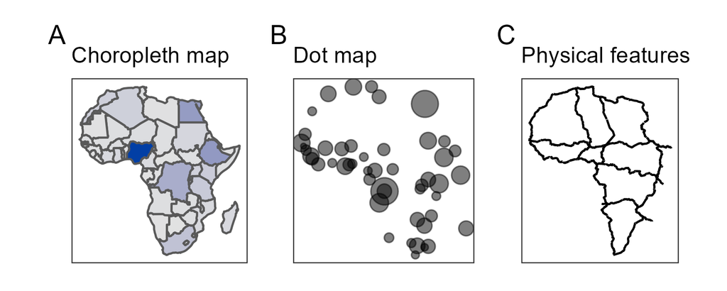

Figure 1. (A) Estimated population of each country in the African continent.; (B) Number of inhabitants in each capital city of the African continent. (C) African trans-continental highway network lines.

For all of our previous examples we used *Spatial data* recorded inside the `{afrilearndata}` package, like `africapitals`, `africountries`, and `afrihighway`. But, How can we create more *Thematic maps* from **external** Spatial data?

In this lesson we are going to learn how to **read external Spatial data** from *online* repositories.

# 2 Learning objectives

1. Read Spatial data from **online databases** using `{rgeoboundaries}` and `{malariaAtlas}`.
2. Convert foreign objects to **`sf` class** using the `st_as_sf()` function from the `{sf}` package.
3. Relate each Thematic map with a **Vector data** type.

# 3 Prerequisites

This lesson requires the following packages:

```r
if(!require('pacman')) install.packages('pacman')

pacman::p_load(malariaAtlas,
               ggplot2,
               cholera,
               here,
               sf)

pacman::p_load_gh("afrimapr/afrilearndata",
                  "wmgeolab/rgeoboundaries")
```

# 4 From Online databases

Here we are going to explore two `{packages}` that **connect** our environment to web repositories and facilitate the downloading of external data. This procedure *do not need* URL paths, only specific *arguments* inside a function.

## 4.1 Boundaries of countries with `rgeoboundaries`

The [`rgeoboundaries`](https://github.com/wmgeolab/rgeoboundaries) package is a client for the [geoBoundaries API](https://www.geoboundaries.org/), providing country political administrative boundaries.

### A single country

To download boundaries of countries we use the `geoboundaries()` function of `{rgeoboundaries}`. For example, we can download the administrative boundary of Zimbabwe and assign it to a variable called `zimbabwe_boundary` as follows.

```r
zimbabwe_boundary <- geoboundaries(country = "Zimbabwe")
```

- The `zimbabwe_boundary` is a `"sf"` class object.
- `{ggplot2}` allows us to easily visualise **simple feature** objects using the `geom_sf()` function.
- It can be used to plot the administrative boundary of Zimbabwe as follows:

```r
ggplot(data = zimbabwe_boundary) +
  geom_sf()
```

[output not shown]

Download the boundaries of `Sierra Leone` using the `geoboundaries()` function.

```r
q1 <- ________(country = "Sierra Leone")
q1
```

### Different levels of administrative boundaries

If available, lower levels of administrative boundaries in countries can be downloaded too. We just have to pass the administrative level as an argument in the `geoboundaries()` function.

Administrative **level 1** (`1`) is the highest level, while administrative **level 5** (`5`) is the lowest. This means the country will be further sub-divided into administrative divisions as the Administrative level progresses from 1 to 5.

See how the first and second administrative level boundaries of Zimbabwe are downloaded below.

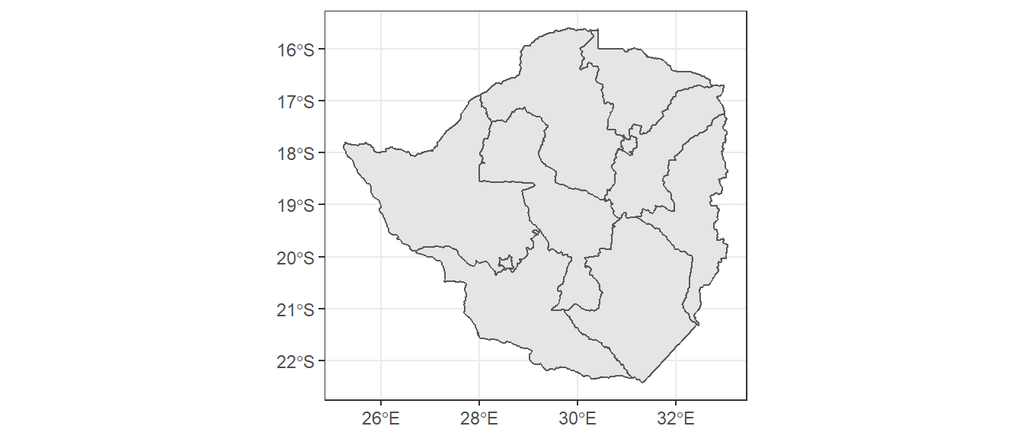

```r
# downloading administrative level 1 boundaries
zimbabwe_boundaries_adm1 <- geoboundaries(country = "Zimbabwe",
                                         adm_lvl = 1)

ggplot(data = zimbabwe_boundaries_adm1) +
  geom_sf()
```

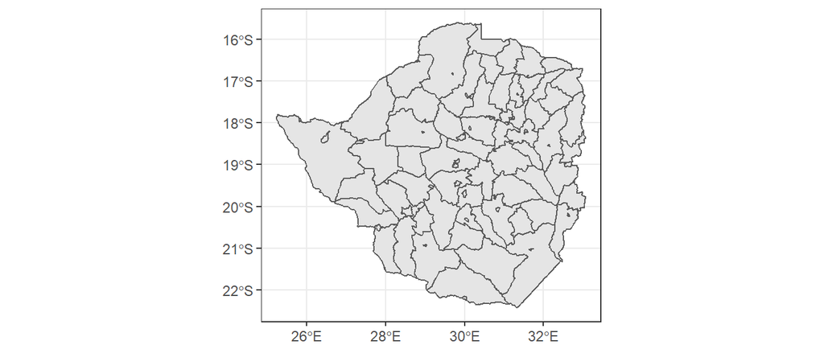

```r
# downloading administrative level 2 boundaries
zimbabwe_boundaries_adm2 <- geoboundaries(country = "Zimbabwe",
                                         adm_lvl = 2)

ggplot(data = zimbabwe_boundaries_adm2) +
  geom_sf()
```

Download the `third` administrative level boundaries of `Sierra Leone`.

```r
q2 <- ________(country = "Sierra Leone", adm_lvl = ________)
q2
```

We can also download the boundaries of **multiple countries** together by including the names of countries as a `vector` class object like: `c("country_01","country_02")`.

See how the `second` administrative level boundaries of adjacent countries like `Zimbabwe` and `Mozambique` are downloaded and plotted below.

```r
zimbabwe_mozambique_adm2 <-
  geoboundaries(country = c("Zimbabwe", "Mozambique"),
                                   adm_lvl = 2)
```

```r
ggplot(data = zimbabwe_mozambique_adm2) +
  geom_sf()
```

[output not shown]

## 4.2 Disease information with `malariaAtlas`

The `malariaAtlas` package download, visualize and manipulate global malaria data hosted by the [Malaria Atlas Project](https://malariaatlas.org/).

The `malariaAtlas` package enables users to download data like:

- parasite rate (PR) survey data (*Plasmodium falciparum* and *Plasmodium vivax*)
- mosquito occurrence data

### Parasite Rate surveys

The `getPR()` function downloads all the publicly available PR points for a country (or countries) and returns it as a dataframe. The `species` argument is a string specifying the Plasmodium species and can be `Pf` (*Plasmodium falciparum*), `Pv` (*Plasmodium vivax*) or `BOTH`.

```r
zimbabwe_malaria_pr <- getPR(country = "Zimbabwe", species = "BOTH")
```

The output is a `data.frame` object that contains `longitude` and `latitude` as variables:

```r
class(zimbabwe_malaria_pr)
```

```
## [1] "pr.points"  "data.frame"
```

```r
zimbabwe_malaria_pr %>%
  as_tibble()
```

```
## # A tibble: 567 × 28
##    dhs_id site_id site_name      latit…¹ longi…² rural…³ country count…⁴ conti…⁵
##    <lgl>    <int> <chr>            <dbl>   <dbl> <chr>   <chr>   <chr>   <chr>
##  1 NA       16142 Chilonga         -18.4    27.2 UNKNOWN Zimbab… ZWE     Africa
##  2 NA       17018 Ume - Kahobo     -17.8    28.8 UNKNOWN Zimbab… ZWE     Africa
##  3 NA       18443 Bandanyenje      -18.9    32.0 UNKNOWN Zimbab… ZWE     Africa
##  4 NA          68 Piringani        -17.0    30.1 UNKNOWN Zimbab… ZWE     Africa
##  5 NA       19390 Zidulini         -18.7    28.7 UNKNOWN Zimbab… ZWE     Africa
##  6 NA       17564 Lutumba          -22.1    30.2 UNKNOWN Zimbab… ZWE     Africa
##  7 NA       14287 Seula School     -21.6    28.4 UNKNOWN Zimbab… ZWE     Africa
##  8 NA        2943 Ndlovu           -18.9    27.8 UNKNOWN Zimbab… ZWE     Africa
##  9 NA       11029 Bambaninga       -20.4    31.8 UNKNOWN Zimbab… ZWE     Africa
## 10 NA       20058 Pumula Mission   -19.6    27.1 UNKNOWN Zimbab… ZWE     Africa
## # … with 557 more rows, 19 more variables: month_start <int>, year_start <int>,
## #   month_end <int>, year_end <int>, lower_age <int>, upper_age <int>,
## #   examined <int>, positive <int>, pr <dbl>, species <chr>, method <chr>,
## #   rdt_type <chr>, pcr_type <lgl>, malaria_metrics_available <chr>,
## #   location_available <chr>, permissions_info <chr>, citation1 <chr>,
## #   citation2 <chr>, citation3 <chr>, and abbreviated variable names ¹latitude,
## #   ²longitude, ³rural_urban, ⁴country_id, ⁵continent_id
## # ℹ Use `print(n = ...)` to see more rows, and `colnames()` to see all variable names
```

Download the publicly available Parasite Ratio (PR) points for *Plasmodium falciparum* in `Sierra Leone`.

```r
q3 <- getPR(country = "Sierra Leone",species = "__")
q3
```

`autoplot()` can be used to quickly and easily visualise the downloaded PR survey points.

```r
autoplot(zimbabwe_malaria_pr)
```

[output not shown]

However, if you would like to make a **custom plot** for your particular research needs, with complete control of the *output aesthetics*, you would probably prefer `{ggplot2}` for the work!

### Convert a foreign object to `sf`

To convert a `data.frame` to an `sf` object, we can use the `st_as_sf()` from the `{sf}` package.

In case of **Point** patterns data (like for a **Dot map**):

- the `coords` argument need to specify the names of the variables holding the **Coordinates**, and
- the `crs` argument specify the **Coordinate Reference System (CRS)** to be assigned (here WGS84, which is the CRS code #`4326`).

```r
zimbabwe_malaria_pr_sf <-
  # data frame
  zimbabwe_malaria_pr %>%
  # convert to sf
  sf::st_as_sf(coords = c("longitude","latitude"),
               crs = 4326)
```

Inside the **`coords` argument**,you need to pay attention to two things:

- You need to use `"quotation_marks"` for each column name,
- First write the `longitude`, and then the `latitude`.

Does this CRS business sound like gibberish to you? DON’T PANIC ! We are going to cover this SOON in the coming lessons. We will see what “WGS84” stands for and how to choose the right CRS for our plots. For now, trust me on this.

**Mission accomplished!** This is the output of the convertion:

```r
zimbabwe_malaria_pr_sf
```

```
## Simple feature collection with 567 features and 26 fields
## Geometry type: POINT
## Dimension:     XY
## Bounding box:  xmin: 25.8063 ymin: -22.2333 xmax: 32.9708 ymax: -16.0662
## Geodetic CRS:  WGS 84
## First 10 features:
##    dhs_id site_id      site_name rural_urban  country country_id continent_id
## 9      NA   16142       Chilonga     UNKNOWN Zimbabwe        ZWE       Africa
## 11     NA   17018   Ume - Kahobo     UNKNOWN Zimbabwe        ZWE       Africa
## 17     NA   18443    Bandanyenje     UNKNOWN Zimbabwe        ZWE       Africa
## 19     NA      68      Piringani     UNKNOWN Zimbabwe        ZWE       Africa
## 21     NA   19390       Zidulini     UNKNOWN Zimbabwe        ZWE       Africa
## 24     NA   17564        Lutumba     UNKNOWN Zimbabwe        ZWE       Africa
## 26     NA   14287   Seula School     UNKNOWN Zimbabwe        ZWE       Africa
## 30     NA    2943         Ndlovu     UNKNOWN Zimbabwe        ZWE       Africa
```

[output cut: 79 more lines]

Now we have converted our data into an `sf` object and can directly plot this object with `{ggplot2}` code:

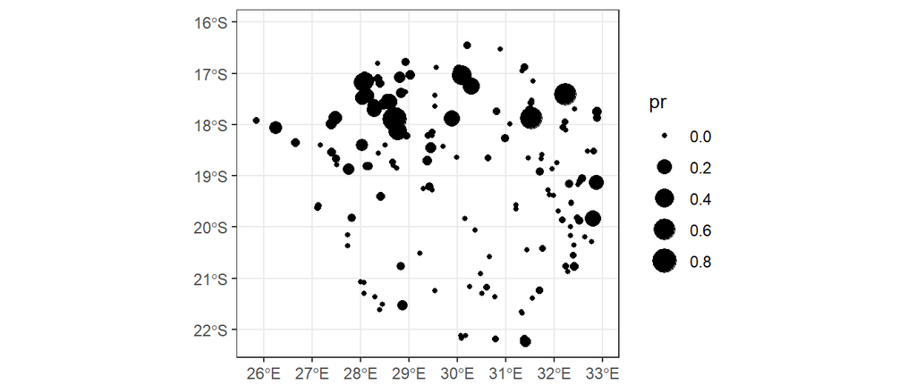

```r
ggplot(data = zimbabwe_malaria_pr_sf) +
  geom_sf(aes(size = pr))
```

Or add one previous layer with the administrative boundaries of Zimbabwe:

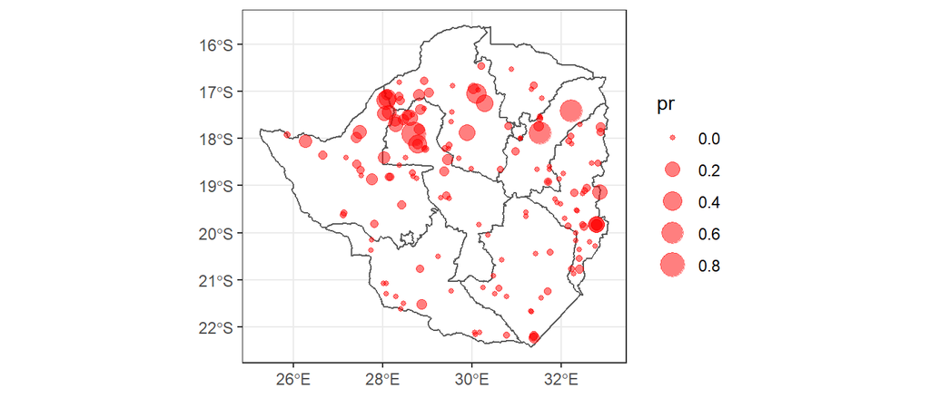

```r
ggplot() +
  # boundaries data
  geom_sf(data = zimbabwe_boundaries_adm1,
          fill = "white") +
  # disease data
  geom_sf(data = zimbabwe_malaria_pr_sf,
          aes(size = pr),
          color = "red",
          alpha=0.5)
```

`sf::st_as_sf()` does not allow missing values in coordinates!

So you can use `{dplyr}` verbs like `filter()` to drop problematic rows from variable `x` using this notation:`filter(!is.na(x))`.

With the publicly available Parasite Ratio (PR) points of *Plasmodium falciparum* in Sierra Leone stored in `q3`:

Convert its `data.frame` output to a `sf` object using the `st_as_sf()` function, with the code `4326` to set a `WGS84` CRS. (More on all these codes coming soon, don’t be intimidated !)

```r
q4 <-
  q3 %>%
  filter(!is.na(longitude)) %>%
  sf::________(coords = c("________","________"),
               crs = 4326)
q4
```

### Vector data

**Vector Data** is the most common format of *Spatial data* used in GIS. *Vector data* provides sufficient information about where different features should be, in relation to one another.

- When we collect *Point* pattern data, used to create *Dot maps*, we need to use a **Vector data** type called **Point** geometry.
- When we collect *Areal* data, used to create *Choropleth maps*, we need to use a **Vector data** type called **Polygon** geometry.

Above is an example of converting foreign **Point** data to `sf` class. Now let’s see briefly see how to convert foreign **Areal** data.

Here is an example, using an alternative way to download administrative boundaries using `raster::getData()``:

1. We get *level 2* administrative boundaries data from the [GADM](https://gadm.org/) online repository.
2. Countries are specified by their [3 letter ISO codes](https://en.wikipedia.org/wiki/List_of_ISO_3166_country_codes#Current_ISO_3166_country_codes).

```r
pacman::p_load(raster)
sle_polygon <- getData(name = 'GADM', country = 'SLE', level = 2)
sle_polygon
```

```
## class       : SpatialPolygonsDataFrame
## features    : 14
## extent      : -13.30351, -10.26575, 6.917616, 10.00043  (xmin, xmax, ymin, ymax)
## crs         : +proj=longlat +datum=WGS84 +no_defs
## variables   : 13
## names       : GID_0,       NAME_0,   GID_1,  NAME_1, NL_NAME_1,     GID_2,        NAME_2, VARNAME_2, NL_NAME_2,   TYPE_2, ENGTYPE_2, CC_2,   HASC_2
## min values  :   SLE, Sierra Leone, SLE.1_1, Eastern,        NA, SLE.1.1_1,            Bo,  Freetown,        NA,     Area,      Area,   NA, SL.EA.KE
## max values  :   SLE, Sierra Leone, SLE.4_1, Western,        NA, SLE.4.2_1, Western Urban,  Freetown,        NA, District,  District,   NA, SL.WE.WU
```

3. Countries are *areas* (i.e. Spatial **Polygons**) hence we need to convert these area coordinates to an `sf` object.

```r
sle_polygon %>% class()
```

```
## [1] "SpatialPolygonsDataFrame"
## attr(,"package")
## [1] "sp"
```

4. Let’s see how this translated into code (reminder: you do not need to use any argument inside `st_as_sf()`):

```r
sle_polygon %>% sf::st_as_sf() %>% class()
```

```
## [1] "sf"         "data.frame"
```

5. With this `sf` object we can easily make plots with {ggplot2}

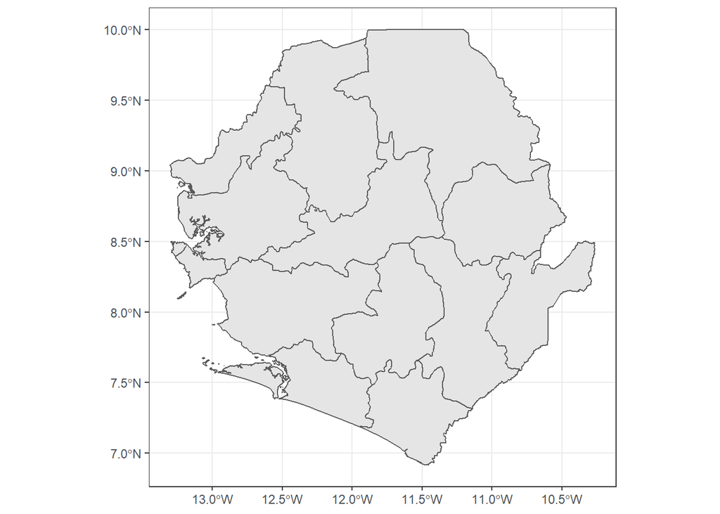

```r
sle_polygon %>%
  sf::st_as_sf() %>%
  ggplot() +
  geom_sf()
```

Do not get confused by the `vector` class object, which is an R class just like `data.frame` and `matrix`.

*Vector data* require a **Coordinate Reference System (CRS)** to relate the spatial elements of the data with the *surface of Earth*.

Degrees of **longitude/latitude** are the most common.

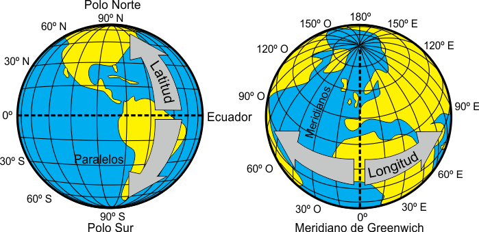

For now, it is sufficient to know that coordinate systems are a *key component* of geographic objects. We will cover them in detail later !

# 5 Wrap up

In this lesson, we have learned how to **read** Vector data like *Polygon geometries* from *Online databases* from the `{rgeoboundaries}` package and `GADM` repository, how to **convert** foreign *Point geometries* to `sf` from the `{malariaAtlas}` package, and why they need a *Coordinate Reference Systems (CRS)*.

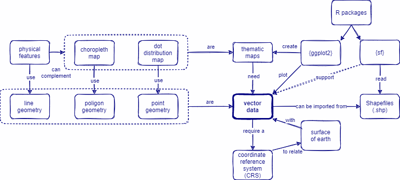

Figure 5. Concept map

In the next lesson we are going dive into **Vector data** components and how to read it from **local files**!

# Contributors

The following team members contributed to this lesson:

- [ANDREE VALLE CAMPOS](https://thegraphcourses.org/members/avallecam/)  
  R Developer and Instructor, The Graph Network

  Motivated by reproducible science and education.
- [LAURE VANCAUWENBERGHE](https://thegraphcourses.org/members/lolovanco)  
  Data analyst, the GRAPH Network

  A firm believer in science for good, striving to ally programming, health and education.

# References

Some material in this lesson was adapted from the following sources:

- *Seimon, Dilinie. Administrative Boundaries.* (2021). Retrieved 15 April 2022, from https://rspatialdata.github.io/admin_boundaries.html
- *Varsha Ujjinni Vijay Kumar. Malaria.* (2021). Retrieved 15 April 2022, from https://rspatialdata.github.io/malaria.html
- *Batra, Neale, et al. The Epidemiologist R Handbook. Chapter 28: GIS Basics*. (2021). Retrieved 01 April 2022, from https://epirhandbook.com/en/gis-basics.html
- *Lovelace, R., Nowosad, J., & Muenchow, J. Geocomputation with R. Chapter 2: Geographic data in R*. (2019). Retrieved 01 April 2022, from https://geocompr.robinlovelace.net/spatial-class.html
- *Moraga, Paula. Geospatial Health Data: Modeling and Visualization with R-INLA and Shiny. Chapter 2: Spatial data and R packages for mapping*. (2019). Retrieved 01 April 2022, from https://www.paulamoraga.com/book-geospatial/sec-spatialdataandCRS.html

This work is licensed under the [Creative Commons Attribution Share Alike](https://creativecommons.org/licenses/by-sa/4.0/) license.